# Network and igraph

April 2, 2018

## What is graph (Network) ?

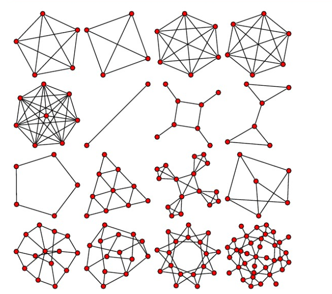

Network1

## What is graph (Network) ?

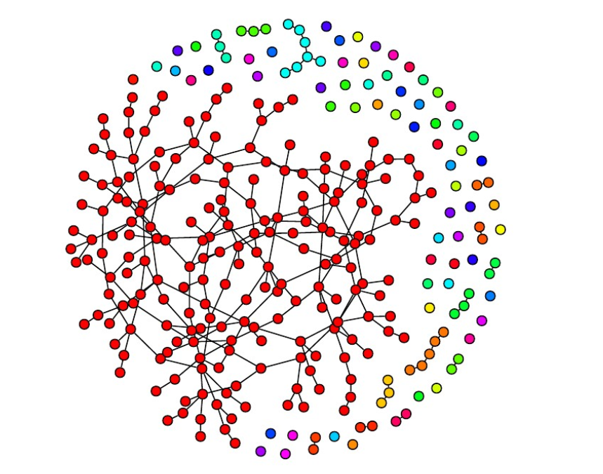

Network2

## What is graph (Network) ?

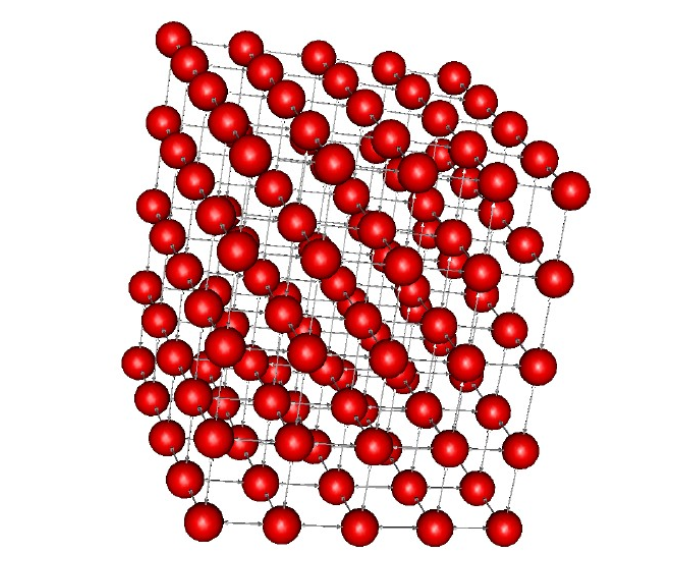

Network3

## Undirected and directored graph

- If the pairs are unordered, then the graph is undirected

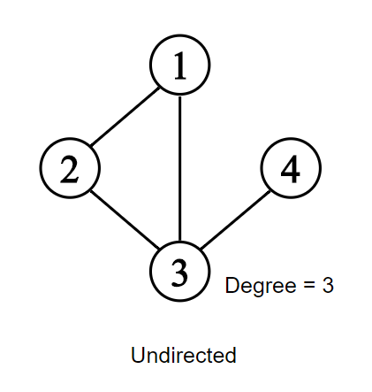

Network4

## Undirected and directed graph

- Otherwise, it is directed

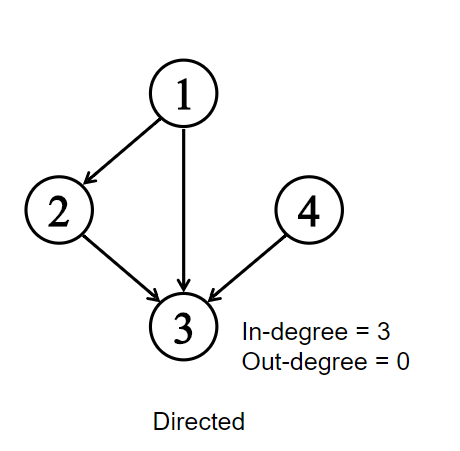

Network5

## Weighted and unweighted graph

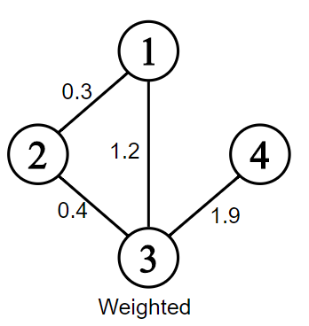

Network6

## Weighted and unweighted graph

- Otherwise, it is unweighted

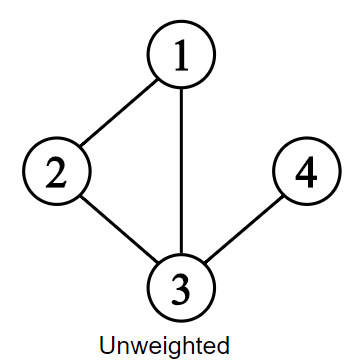

Network7

## Features of graphs

- Random Network  
  Randomply connecting pairs of nodes with some probabily \(p\)
- Scale-Free Network Few nodes has a large number of links, most nodes have very few.

## Random Network

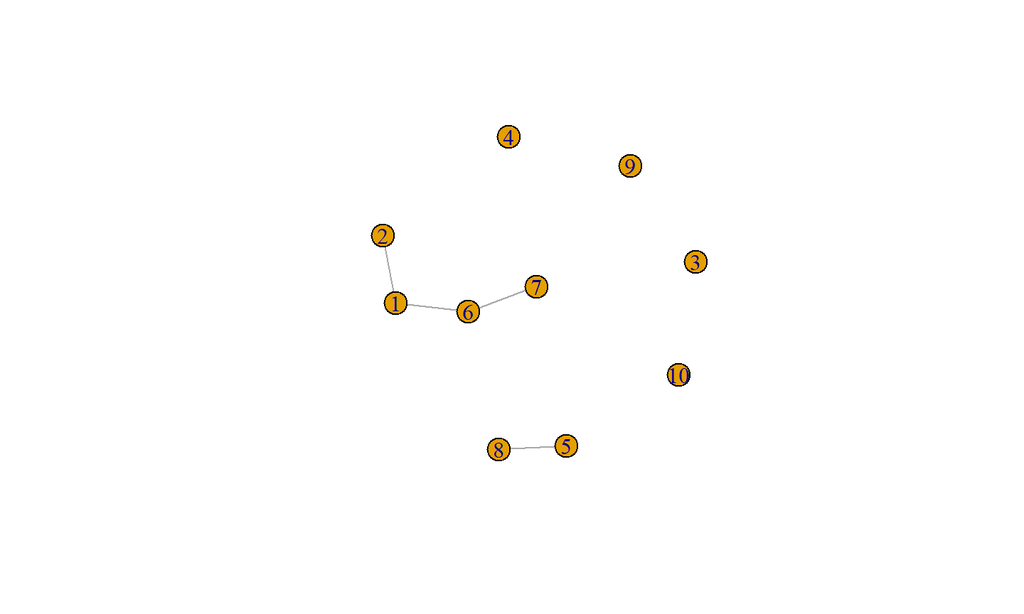

```r
## Random Graph
g <- erdos.renyi.game(10, 1/10)
plot(g)
```

```r
degree_distribution(g)
```

```
## [1] 0.4 0.4 0.2
```

## Scale-Free Network

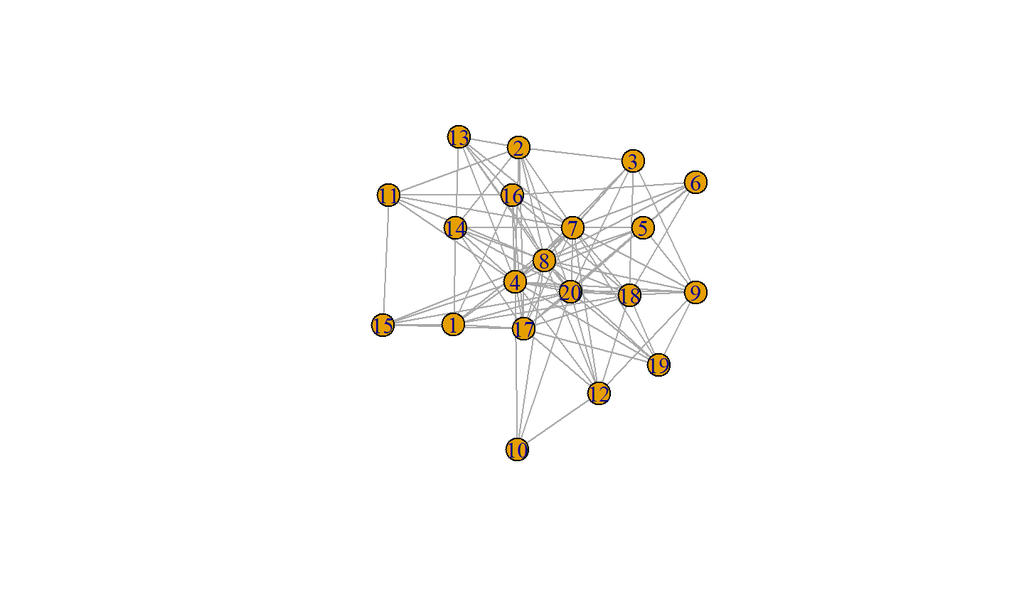

```r
## Scale Free
N <- 20
g <- sample_fitness(5*N, sample((1:20)^-2, N, replace=TRUE))
plot(g)
```

## Igraph package

- For classic graph theory and network science
- Core functionally is implemented as a C library
- High level interfaces from R and Python
- http: //igraph.sf.net

## Vertex and edge ids

V = {A,B,C,D,E}  
Edges = ((A,B),(A,C),(B,C),(C,E))  
A = 1, B = 2, C = 3, D = 4, E = 5

```
g <- graph(c(1,2, 1,3, 2,3, 3,5),n =5)
```

## Vertex and edge ids

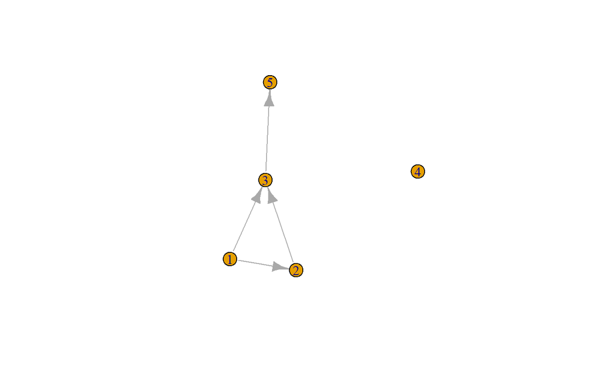

```r
g <- graph(c(1,2, 1,3, 2,3, 3,5),n =5)
plot(g)
```

## Creating igraph graphs

- igraph object

```r
print(g)
```

```
## IGRAPH 356935f D--- 5 4 --
## + edges from 356935f:
## [1] 1->2 1->3 2->3 3->5
```

```r
vcount(g)
```

```
## [1] 5
```

```r
ecount(g)
```

```
## [1] 4
```

## Adjacency matrix

\[ \begin{bmatrix} & A & B & C & D & E\\ A & 0 & 1 & 1 & 0 & 0\\ B & 1 & 0 & 1 & 0 & 0\\ C & 1 & 1 & 0 & 0 & 1\\ D & 0 & 0 & 0 & 0 & 0\\ E & 0 & 0 & 1 & 0 & 0 \end{bmatrix} \]

## Strongly Connected Components

A directed graph is called strongly connected if there is a path in each direction between each pair of vertices of the graph.

– In a directed graph G that may not itself be strongly connected, a pair of vertices u and v are said to be strongly connected to each other if there is a path in each direction between them.

## SCC

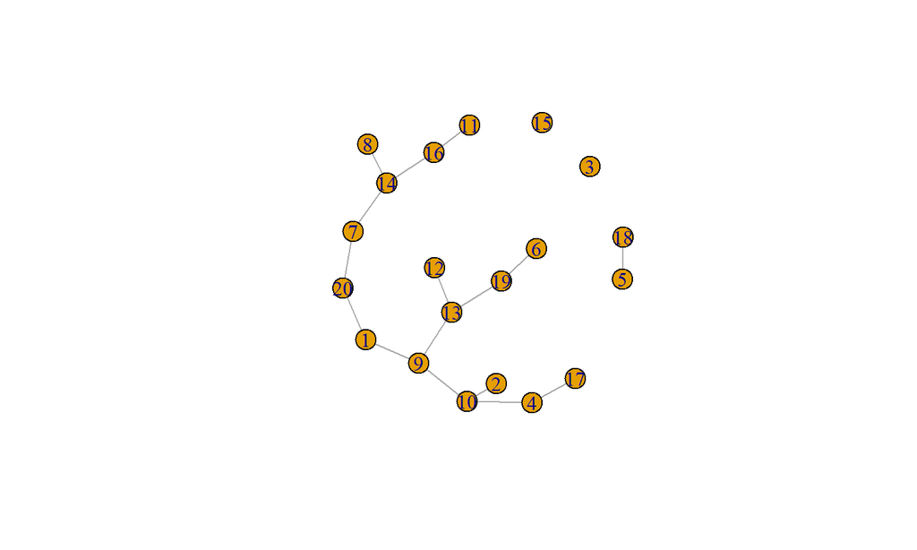

```r
g <- erdos.renyi.game(20, 1/15)
plot.igraph(g)
```

## Homework

**Either**: Just simulate a random graph (n = 10, p = 0.3) and print out its adjacency matrix

**Or**: Download any network data and print it as a graph.